# Predicting Life expectancy using Regression

2024-03-21

## Import packages for the analysis

```r
library(tidyverse)
library(skimr)
library(here)
library(caret)
```

```r
library(corrplot)
```

## Read in the data from the project folder

```r
data <- read.csv(here("Supervised Learning/data", "Life_Expectancy_Data.csv"))
```

## Data Cleaning and Exploration

We take a brief look at the dataset.

```r
skim_without_charts(data)
```

Data summary

| Name | data |
| --- | --- |
| Number of rows | 2848 |
| Number of columns | 23 |
| _______________________ |  |
| Column type frequency: |  |
| character | 2 |
| numeric | 21 |
| ________________________ |  |
| Group variables | None |

**Variable type: character**

| skim_variable | n_missing | complete_rate | min | max | empty | n_unique | whitespace |
| --- | --- | --- | --- | --- | --- | --- | --- |
| Country | 0 | 1 | 4 | 30 | 0 | 178 | 0 |
| Region | 0 | 1 | 4 | 29 | 0 | 9 | 0 |

**Variable type: numeric**

| skim_variable | n_missing | complete_rate | mean | sd | p0 | p25 | p50 | p75 | p100 |
| --- | --- | --- | --- | --- | --- | --- | --- | --- | --- |
| Year | 0 | 1 | 2007.50 | 4.61 | 2000.00 | 2003.75 | 2007.50 | 2011.25 | 2015.00 |
| Economy_status_Developed | 0 | 1 | 0.21 | 0.41 | 0.00 | 0.00 | 0.00 | 0.00 | 1.00 |
| Life_expectancy | 0 | 1 | 68.95 | 9.34 | 39.40 | 62.90 | 71.45 | 75.50 | 83.80 |
| Adult_mortality | 0 | 1 | 190.90 | 113.79 | 49.38 | 106.68 | 163.28 | 245.32 | 719.36 |
| Infant_deaths | 0 | 1 | 30.08 | 27.35 | 1.80 | 8.10 | 19.40 | 47.00 | 138.10 |
| Alcohol_consumption | 0 | 1 | 4.84 | 3.99 | 0.00 | 1.22 | 4.05 | 7.81 | 17.87 |
| percentage.expenditure | 0 | 1 | 785.16 | 2078.01 | 0.00 | 6.91 | 71.85 | 470.53 | 19479.91 |
| Hepatitis_B | 0 | 1 | 64.65 | 39.38 | 0.00 | 9.00 | 86.00 | 96.00 | 99.00 |
| Measles | 0 | 1 | 2129.25 | 10410.84 | 0.00 | 0.00 | 15.00 | 309.00 | 212183.00 |
| BMI | 0 | 1 | 37.76 | 20.61 | 0.00 | 18.80 | 43.10 | 56.30 | 79.30 |
| Under_five_deaths | 0 | 1 | 40.05 | 161.33 | 0.00 | 0.00 | 3.00 | 24.25 | 2500.00 |
| Polio | 6 | 1 | 80.94 | 25.91 | 0.00 | 76.00 | 93.00 | 97.00 | 99.00 |
| Total.expenditure | 0 | 1 | 5.40 | 2.95 | 0.00 | 3.64 | 5.48 | 7.32 | 17.60 |
| Income.composition.of.resources | 0 | 1 | 0.60 | 0.25 | 0.00 | 0.47 | 0.67 | 0.78 | 0.95 |
| Diphtheria | 0 | 1 | 86.34 | 15.54 | 16.00 | 81.00 | 93.00 | 97.00 | 99.00 |
| Incidents_HIV | 0 | 1 | 0.89 | 2.39 | 0.01 | 0.08 | 0.15 | 0.44 | 21.68 |
| GDP_per_capita | 0 | 1 | 11596.33 | 16966.12 | 148.00 | 1404.25 | 4256.50 | 12706.75 | 112418.00 |
| Population_mln | 0 | 1 | 36.77 | 136.86 | 0.08 | 2.07 | 7.73 | 23.85 | 1379.86 |
| Thinness_ten_nineteen_years | 0 | 1 | 4.86 | 4.45 | 0.10 | 1.60 | 3.30 | 7.20 | 27.70 |
| Thinness_five_nine_years | 0 | 1 | 4.89 | 4.54 | 0.10 | 1.60 | 3.30 | 7.30 | 28.60 |
| Schooling | 0 | 1 | 7.65 | 3.17 | 1.10 | 5.10 | 7.90 | 10.30 | 14.10 |

Notice that the data is panel data. So it includes both cross sectional data collected amongst several variables, and also data collected over time. To reduce the complication associated with analyzing time series data, we pick data from a single year: 2014, which is the latest data that is completely available. We also drop our identifying variables: country and region, since these will not affect our results.

```r
data_2014 <- data %>% filter(Year == 2014) %>% select(-c(Year, Region, Country))
```

An analysis of the variables does not reveal any evidence of outliers or missing values, so we will skip those aspects in this presentation. However, running the code block below will give a quick overview of the dataset stats

```r
skim_without_charts(data_2014)
```

Data summary

| Name | data_2014 |
| --- | --- |
| Number of rows | 178 |
| Number of columns | 20 |
| _______________________ |  |
| Column type frequency: |  |
| numeric | 20 |
| ________________________ |  |
| Group variables | None |

**Variable type: numeric**

| skim_variable | n_missing | complete_rate | mean | sd | p0 | p25 | p50 | p75 | p100 |
| --- | --- | --- | --- | --- | --- | --- | --- | --- | --- |
| Economy_status_Developed | 0 | 1 | 0.21 | 0.41 | 0.00 | 0.00 | 0.00 | 0.00 | 1.00 |
| Life_expectancy | 0 | 1 | 71.31 | 7.99 | 49.90 | 66.15 | 72.80 | 76.68 | 83.60 |
| Adult_mortality | 0 | 1 | 165.21 | 90.53 | 50.00 | 92.84 | 147.10 | 214.43 | 518.28 |
| Infant_deaths | 0 | 1 | 24.00 | 21.83 | 1.90 | 6.82 | 15.40 | 37.12 | 95.60 |
| Alcohol_consumption | 0 | 1 | 4.78 | 3.79 | 0.00 | 1.37 | 4.22 | 7.78 | 17.29 |
| percentage.expenditure | 0 | 1 | 1027.16 | 2584.27 | 0.00 | 12.96 | 157.04 | 719.84 | 19479.91 |
| Hepatitis_B | 0 | 1 | 76.81 | 31.21 | 0.00 | 73.50 | 91.50 | 96.00 | 99.00 |
| Measles | 0 | 1 | 1669.42 | 8548.97 | 0.00 | 0.00 | 10.50 | 276.75 | 79563.00 |
| BMI | 0 | 1 | 39.94 | 22.10 | 0.00 | 22.70 | 46.50 | 59.88 | 77.10 |
| Under_five_deaths | 0 | 1 | 30.62 | 113.66 | 0.00 | 0.00 | 3.00 | 19.75 | 1200.00 |
| Polio | 0 | 1 | 82.98 | 23.98 | 0.00 | 79.00 | 93.00 | 97.00 | 99.00 |
| Total.expenditure | 0 | 1 | 6.02 | 2.94 | 0.00 | 4.22 | 5.76 | 7.70 | 17.14 |
| Income.composition.of.resources | 0 | 1 | 0.65 | 0.22 | 0.00 | 0.53 | 0.71 | 0.80 | 0.94 |
| Diphtheria | 0 | 1 | 87.93 | 14.70 | 20.00 | 86.00 | 94.00 | 97.00 | 99.00 |
| Incidents_HIV | 0 | 1 | 0.64 | 1.75 | 0.01 | 0.08 | 0.14 | 0.38 | 15.74 |
| GDP_per_capita | 0 | 1 | 12404.72 | 17439.80 | 328.00 | 1609.75 | 5250.50 | 13894.25 | 105584.00 |
| Population_mln | 0 | 1 | 39.73 | 145.65 | 0.09 | 2.32 | 8.73 | 26.93 | 1371.86 |
| Thinness_ten_nineteen_years | 0 | 1 | 4.54 | 4.17 | 0.10 | 1.50 | 3.30 | 6.68 | 26.80 |
| Thinness_five_nine_years | 0 | 1 | 4.69 | 4.27 | 0.10 | 1.50 | 3.40 | 6.60 | 27.40 |
| Schooling | 0 | 1 | 8.32 | 3.14 | 1.40 | 5.93 | 8.60 | 10.90 | 14.00 |

## Correlation Matrix

We view the correlation matrix of the dataset to see which dependent variables may be perfectly correlated and would need to be dropped from the model

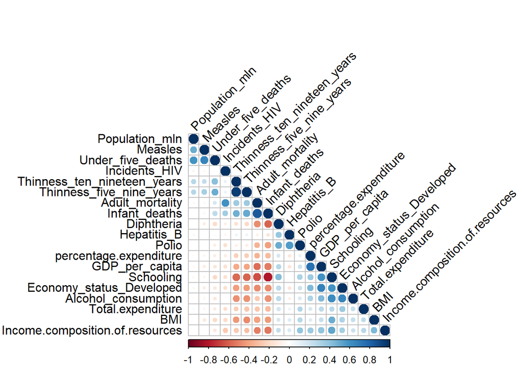

```r
correlation_matrix <- cor(subset(data_2014, select = -Life_expectancy), use = "pairwise.complete.obs")

# Plot the correlation matrix
corrplot(correlation_matrix, method = "circle", type = "lower", order = "hclust", tl.col = "black", tl.srt = 45)
```

```r
correlation_with_dependent <- sapply(data_2014[, -which(names(data_2014) == "Life_expectancy")], function(x) cor(x, data_2014[["Life_expectancy"]]))
correlation_with_dependent
```

```
##        Economy_status_Developed                 Adult_mortality
##                      0.57496539                     -0.95025817
##                   Infant_deaths             Alcohol_consumption
##                     -0.92884861                      0.42851740
##          percentage.expenditure                     Hepatitis_B
##                      0.39867042                      0.07097132
##                         Measles                             BMI
##                     -0.03770939                      0.42722149
##               Under_five_deaths                           Polio
##                     -0.21014936                      0.36126551
##               Total.expenditure Income.composition.of.resources
##                      0.33365668                      0.54831067
##                      Diphtheria                   Incidents_HIV
##                      0.52867219                     -0.46687673
##                  GDP_per_capita                  Population_mln
##                      0.62865982                      0.01495327
##     Thinness_ten_nineteen_years        Thinness_five_nine_years
##                     -0.44242460                     -0.46509575
##                       Schooling
##                      0.76554455
```

While most of the correlations meet the directional expectations, a few are unexpected such as - Alcohol consumption: Alcohol consumption is associated with several health risks so one would expect that it would be negatively correlated with life expectancy. - Diphtheria, Hepatisis_B, Polio: It is also unexpected that the occurence of certain diseases are positively correlated with life expectancy

## Building the Model

First we set seed to make the data reproducible

```r
set.seed(212)
```

next, we split the data into train and test data

```r
train_index <- createDataPartition(data_2014$Life_expectancy, p = 0.8, list = FALSE)
# Create training set
train_data <- data_2014[train_index, ]
y_train <- train_data[["Life_expectancy"]]
x_train <- subset(train_data, select = -Life_expectancy)
# Create testing set
test_data <- data_2014[-train_index, ]
y_test <- test_data[["Life_expectancy"]]
x_test <- subset(test_data, select = -Life_expectancy)
```

We then run the first iteration of the linear regression

```r
full_model <- lm(y_train ~ ., data = x_train)
summary(full_model)
```

```
##
## Call:
## lm(formula = y_train ~ ., data = x_train)
##
## Residuals:
##     Min      1Q  Median      3Q     Max
## -3.7995 -0.7202 -0.0032  0.7442  3.4170
##
## Coefficients:
##                                   Estimate Std. Error t value Pr(>|t|)
## (Intercept)                      8.069e+01  1.345e+00  60.000  < 2e-16 ***
## Economy_status_Developed         9.320e-01  4.742e-01   1.965   0.0516 .
## Adult_mortality                 -5.349e-02  3.738e-03 -14.310  < 2e-16 ***
## Infant_deaths                   -1.203e-01  1.542e-02  -7.801 2.26e-12 ***
## Alcohol_consumption              5.295e-02  4.710e-02   1.124   0.2630
## percentage.expenditure          -1.840e-05  6.515e-05  -0.282   0.7781
## Hepatitis_B                      1.020e-03  5.287e-03   0.193   0.8474
## Measles                          3.676e-05  1.721e-05   2.136   0.0347 *
## BMI                             -4.432e-03  7.258e-03  -0.611   0.5425
## Under_five_deaths               -1.005e-03  1.540e-03  -0.652   0.5154
## Polio                           -1.487e-02  7.346e-03  -2.025   0.0451 *
## Total.expenditure                7.424e-02  4.477e-02   1.658   0.0998 .
## Income.composition.of.resources  1.580e+00  7.176e-01   2.202   0.0296 *
## Diphtheria                       1.094e-02  1.051e-02   1.042   0.2997
## Incidents_HIV                    2.256e-01  1.290e-01   1.749   0.0829 .
## GDP_per_capita                   2.153e-05  1.317e-05   1.635   0.1046
## Population_mln                  -6.746e-04  9.191e-04  -0.734   0.4643
## Thinness_ten_nineteen_years     -3.143e-02  8.176e-02  -0.384   0.7014
## Thinness_five_nine_years         1.862e-03  8.693e-02   0.021   0.9829
## Schooling                        6.705e-02  8.087e-02   0.829   0.4086
## ---
## Signif. codes:  0 '***' 0.001 '**' 0.01 '*' 0.05 '.' 0.1 ' ' 1
##
## Residual standard error: 1.317 on 123 degrees of freedom
## Multiple R-squared:  0.9766, Adjusted R-squared:  0.973
## F-statistic: 269.8 on 19 and 123 DF,  p-value: < 2.2e-16
```

The adjusted r squared is very impressive at 97%. This means that the model is able to explain 97% of the variation in the training data. However, there are several variables in the model that are insignificant. Thus, we try to remove the unnecessary variables using backward feature selection to find the least variables possible that will still explain the same amount of variation

```r
backward_model <- step(full_model, direction = "backward")
```

```
## Start:  AIC=97.19
## y_train ~ Economy_status_Developed + Adult_mortality + Infant_deaths +
##     Alcohol_consumption + percentage.expenditure + Hepatitis_B +
##     Measles + BMI + Under_five_deaths + Polio + Total.expenditure +
##     Income.composition.of.resources + Diphtheria + Incidents_HIV +
##     GDP_per_capita + Population_mln + Thinness_ten_nineteen_years +
##     Thinness_five_nine_years + Schooling
##
##                                   Df Sum of Sq    RSS     AIC
## - Thinness_five_nine_years         1      0.00 213.31  95.187
## - Hepatitis_B                      1      0.06 213.37  95.229
## - percentage.expenditure           1      0.14 213.45  95.279
## - Thinness_ten_nineteen_years      1      0.26 213.57  95.358
## - BMI                              1      0.65 213.96  95.619
## - Under_five_deaths                1      0.74 214.05  95.680
## - Population_mln                   1      0.93 214.24  95.811
## - Schooling                        1      1.19 214.50  95.983
## - Diphtheria                       1      1.88 215.19  96.442
## - Alcohol_consumption              1      2.19 215.50  96.649
## <none>                                         213.31  97.186
## - GDP_per_capita                   1      4.64 217.95  98.261
## - Total.expenditure                1      4.77 218.08  98.348
## - Incidents_HIV                    1      5.30 218.61  98.697
## - Economy_status_Developed         1      6.70 220.01  99.608
## - Polio                            1      7.11 220.42  99.875
## - Measles                          1      7.91 221.22 100.393
## - Income.composition.of.resources  1      8.41 221.72 100.714
## - Infant_deaths                    1    105.54 318.85 152.668
## - Adult_mortality                  1    355.14 568.45 235.351
##
## Step:  AIC=95.19
## y_train ~ Economy_status_Developed + Adult_mortality + Infant_deaths +
##     Alcohol_consumption + percentage.expenditure + Hepatitis_B +
##     Measles + BMI + Under_five_deaths + Polio + Total.expenditure +
##     Income.composition.of.resources + Diphtheria + Incidents_HIV +
##     GDP_per_capita + Population_mln + Thinness_ten_nineteen_years +
##     Schooling
##
##                                   Df Sum of Sq    RSS     AIC
## - Hepatitis_B                      1      0.07 213.38  93.231
```

[output cut: 168 more lines]

```
##     Population_mln
##
##                                   Df Sum of Sq    RSS     AIC
## <none>                                         219.08  85.003
## - Population_mln                   1      3.34 222.42  85.169
## - Total.expenditure                1      4.13 223.21  85.671
## - Alcohol_consumption              1      4.73 223.81  86.059
## - Economy_status_Developed         1      7.09 226.17  87.558
## - Incidents_HIV                    1      7.32 226.40  87.704
## - Polio                            1      7.51 226.59  87.823
## - Measles                          1      7.59 226.67  87.875
## - Income.composition.of.resources  1      8.62 227.71  88.525
## - GDP_per_capita                   1      9.91 228.99  89.331
## - Infant_deaths                    1    189.89 408.97 172.266
## - Adult_mortality                  1    363.46 582.54 222.852
```

```r
summary(backward_model)
```

```
##
## Call:
## lm(formula = y_train ~ Economy_status_Developed + Adult_mortality +
##     Infant_deaths + Alcohol_consumption + Measles + Polio + Total.expenditure +
##     Income.composition.of.resources + Incidents_HIV + GDP_per_capita +
##     Population_mln, data = x_train)
##
## Residuals:
##     Min      1Q  Median      3Q     Max
## -3.7578 -0.7217 -0.0151  0.7484  3.6452
##
## Coefficients:
##                                   Estimate Std. Error t value Pr(>|t|)
## (Intercept)                      8.204e+01  6.949e-01 118.048   <2e-16 ***
## Economy_status_Developed         9.317e-01  4.525e-01   2.059   0.0415 *
## Adult_mortality                 -5.324e-02  3.611e-03 -14.742   <2e-16 ***
## Infant_deaths                   -1.336e-01  1.254e-02 -10.656   <2e-16 ***
## Alcohol_consumption              7.194e-02  4.276e-02   1.682   0.0949 .
## Measles                          2.867e-05  1.346e-05   2.131   0.0350 *
## Polio                           -1.204e-02  5.684e-03  -2.119   0.0360 *
## Total.expenditure                6.746e-02  4.294e-02   1.571   0.1186
## Income.composition.of.resources  1.401e+00  6.171e-01   2.271   0.0248 *
## Incidents_HIV                    2.589e-01  1.238e-01   2.092   0.0383 *
## GDP_per_capita                   2.192e-05  9.005e-06   2.435   0.0163 *
## Population_mln                  -1.118e-03  7.910e-04  -1.414   0.1597
## ---
## Signif. codes:  0 '***' 0.001 '**' 0.01 '*' 0.05 '.' 0.1 ' ' 1
##
## Residual standard error: 1.293 on 131 degrees of freedom
## Multiple R-squared:  0.9759, Adjusted R-squared:  0.9739
## F-statistic:   483 on 11 and 131 DF,  p-value: < 2.2e-16
```

The model is still able to explain 97% variation in the training data after removing several variables

Next we fit our final model on test data and see how it performs on previously unseen data

```r
predictions <- predict(backward_model, newdata = test_data)
mse <- mean((y_test - predictions)^2)
rmse <- sqrt(mse)
rsquared <- R2(predictions, y_test)
print(paste("Mean Squared Error (MSE):", mse))
```

```
## [1] "Mean Squared Error (MSE): 2.47051857609382"
```

```r
print(paste("Root Mean Squared Error (RMSE):", rmse))
```

```
## [1] "Root Mean Squared Error (RMSE): 1.57178833692512"
```

```r
print(paste("Rsquared of prediction on test data:", rsquared))
```

```
## [1] "Rsquared of prediction on test data: 0.96092369043403"
```